# Primers-ggplot2

## coord_flip()

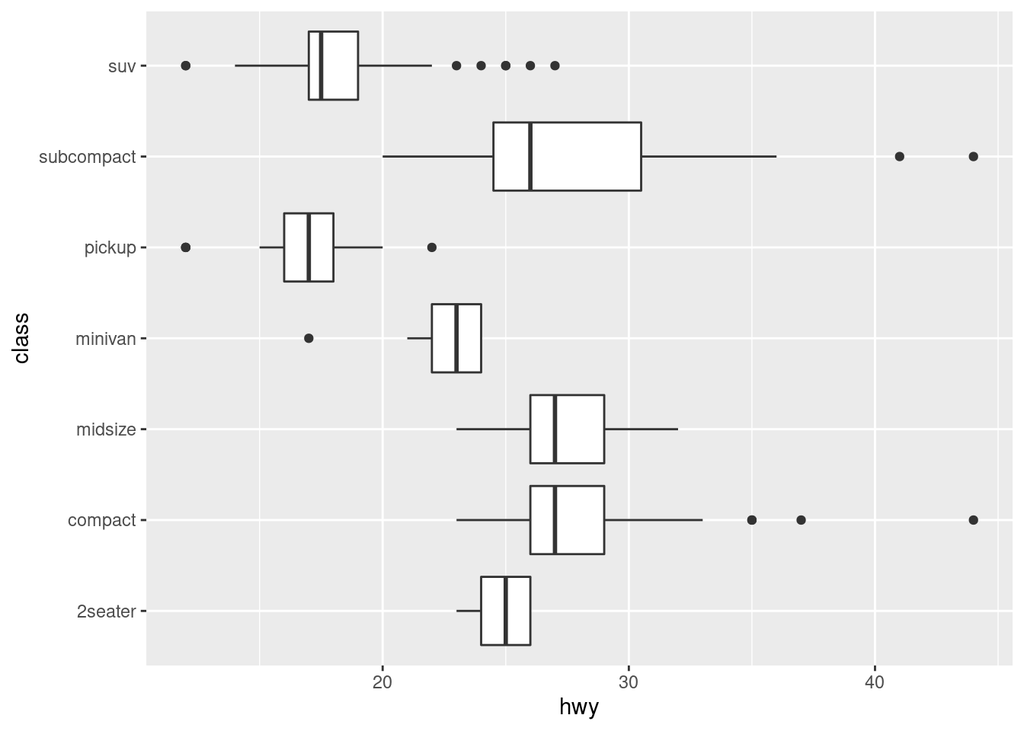

```r
ggplot(data = mpg) +
  geom_boxplot(mapping = aes(x = class, y = hwy))+
  coord_flip()
```

Similar Geoms geom_dotplot()

Boxplots provide a quick way to represent a distribution, but they leave behind a lot of information. ggplot2 supplements boxplots with two geoms that show more information.

The first is geom_dotplot(). If you set the binaxis parameter of geom_dotplot() to “y”, geom_dotplot() behaves like geom_boxplot(), display a separate distribution for each group of data.

Here each group functions like a vertical histogram. Add the parameter stackdir = “center” then re-run the code. Can you interpret the results?

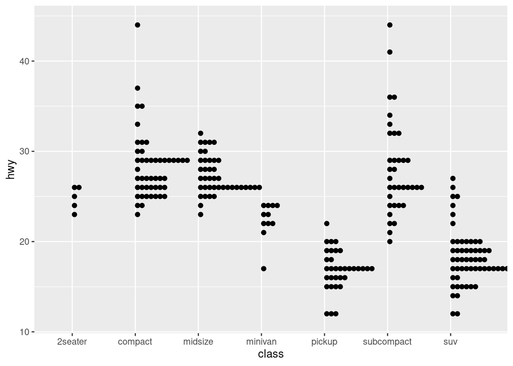

```r
ggplot(data = mpg) +
  geom_dotplot(mapping = aes(x = class, y = hwy), binaxis = "y",
               dotsize = 0.5, binwidth = 1)
```

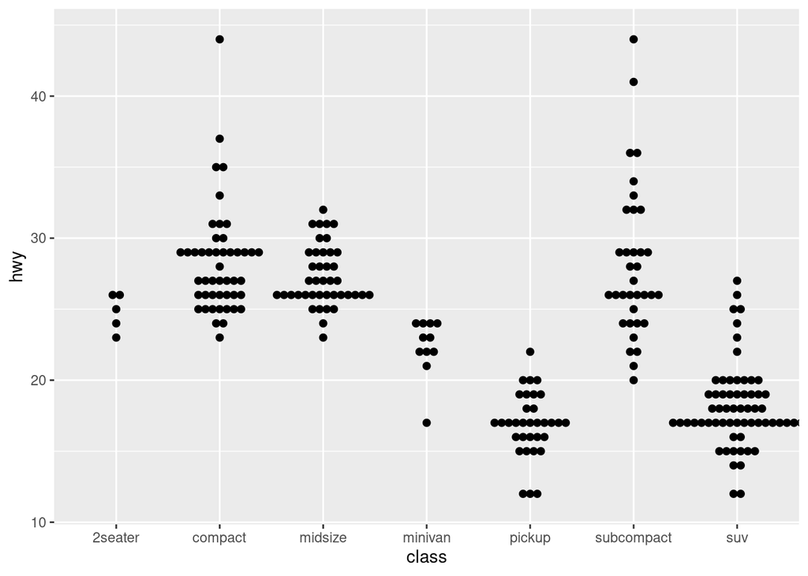

```r
ggplot(data = mpg) +
  geom_dotplot(mapping = aes(x = class, y = hwy), binaxis = "y",
               dotsize = 0.5, binwidth = 1, stackdir = "center")
```

geom_violin()

geom_violin() provides a second alternative to geom_boxplot(). A violin plot uses densities to draw a smoothed version of the centered dotplot you just made.

You can think of a violin plot as an outline drawn around the edges of a centered dotplot. Each “violin” spans the range of the data. The violin is thick where there are many values, and thin where there are few.

Convert the plot below from a boxplot to a violin plot. Note that violin plots do not use the parameters you saw for dotplots.

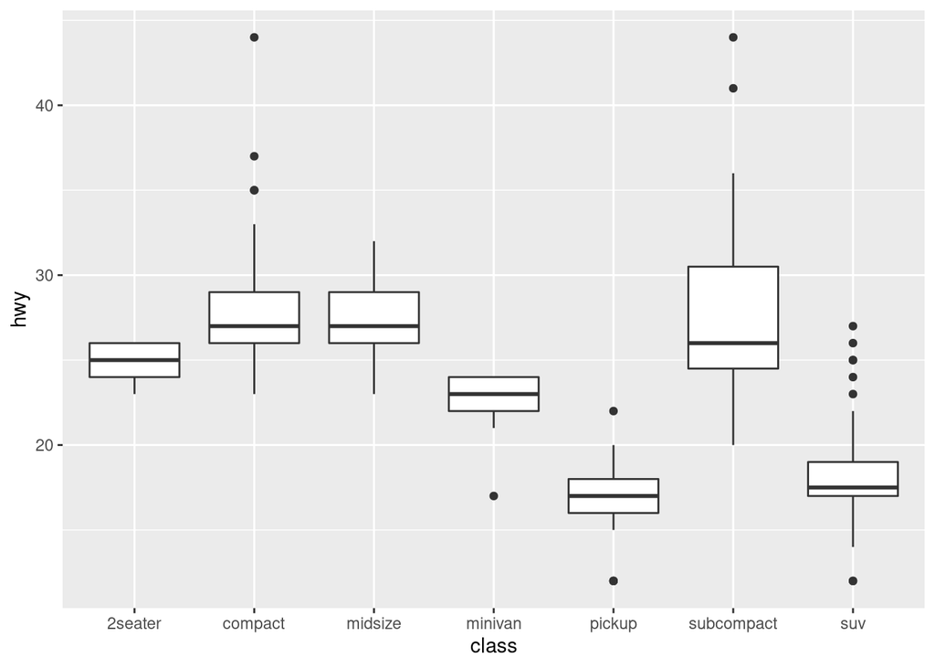

```r
ggplot(data = mpg) +
  geom_boxplot(mapping = aes(x = class, y = hwy))
```

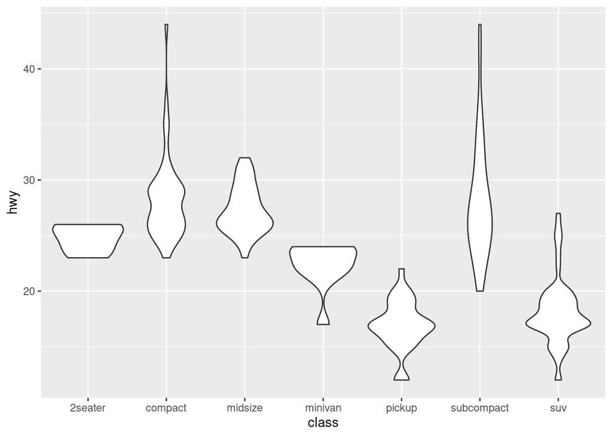

```r
ggplot(data = mpg) +
  geom_violin(mapping = aes(x = class, y = hwy))
```

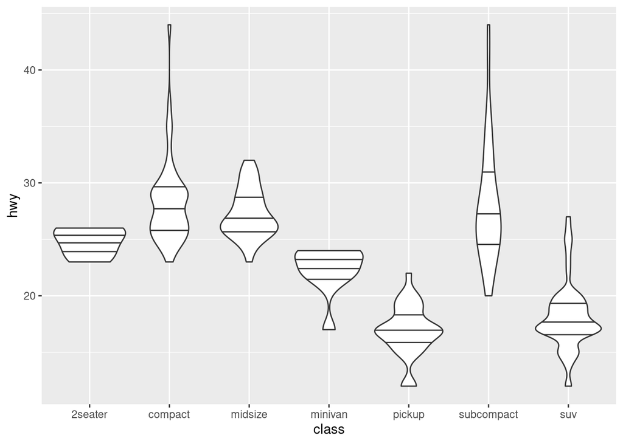

```r
ggplot(data = mpg) +
  geom_violin(mapping = aes(x = class, y = hwy), draw_quantiles =  c(0.25, 0.5, 0.75))
```

geom_count()

Boxplots provide an efficient way to explore the interaction of a continuous variable and a categorical variable. But what if you have two categorical variables?

You can see how observations are distributed across two categorical variables with geom_count(). geom_count() draws a point at each combination of values from the two variables. The size of the point is mapped to the number of observations with this combination of values. Rare combinations will have small points, frequent combinations will have large points.

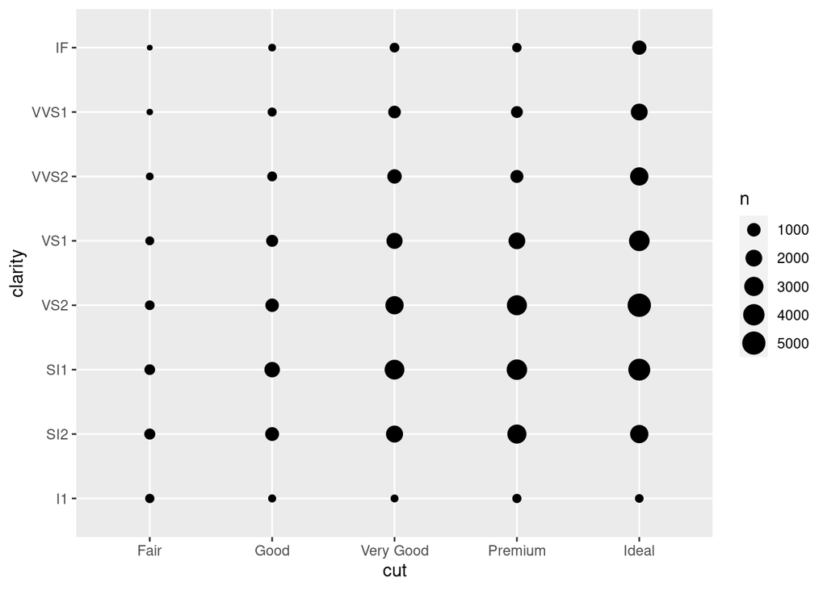

```r
ggplot(data = diamonds) +
  geom_count(mapping = aes(x = cut, y = clarity))
```

Heat maps

Heat maps provide a second way to visualize the relationship between two categorical variables. They work like count plots, but use a fill color instead of a point size, to display the number of observations in each combination.

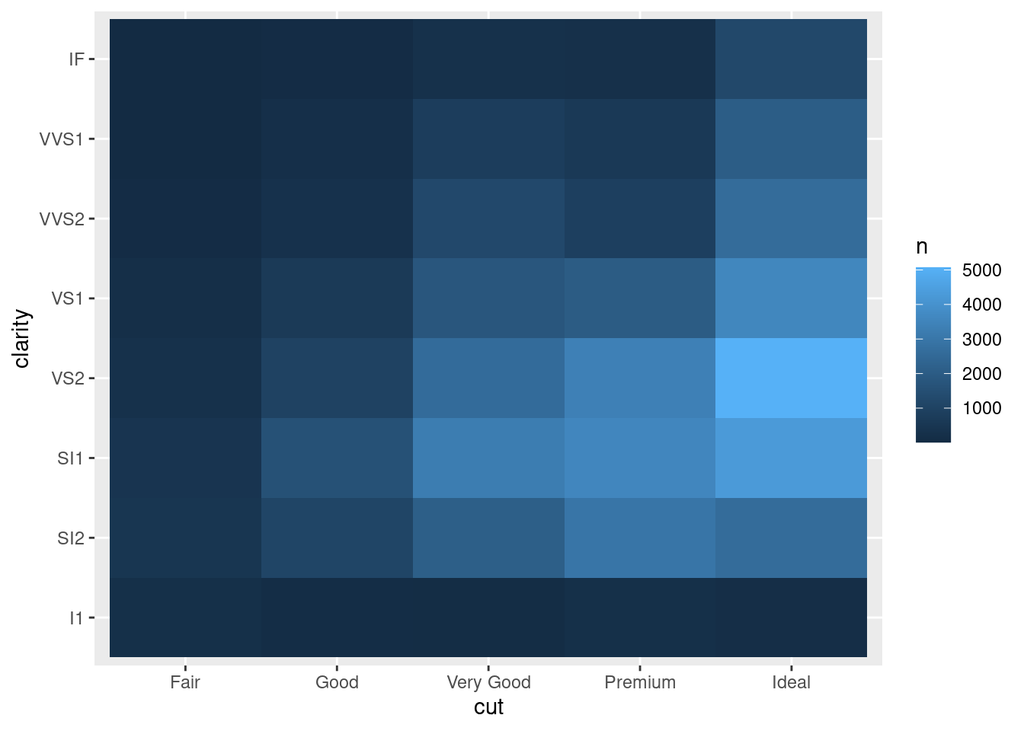

```r
diamonds %>%
   count(cut, clarity) %>%
   ggplot() +
     geom_tile(mapping = aes(x = cut, y = clarity, fill = n))
```